# Report

# Modelli di classificazione per la performance degli studenti

L’Università degli Studi di Milano Centrale è interessata ad individuare i principali fattori che influenzano l’abbandono dei propri corsi universitari, al fine di intervenire con supporti mirati agli studenti.

Il presente progetto ha l’obiettivo di sviluppare un modello di classificazione in grado di prevedere, sulla base di caratteristiche accademiche, demografiche e comportamentali degli studenti, la probabilità e le principali cause di abbandono del percorso di studi.

L’analisi è stata condotta tramite il software R, utilizzando il dataset “Student Dropout Prediction Dataset” disponibile su Kaggle, costruito su una simulazione relativa a 10000 studenti. I dati riproducono fedelmente le distribuzioni reali degli studenti, mantenendo asimmetrie, valori mancanti in alcune osservazioni e correlazioni tra esse.

L’obiettivo dell’elaborato è quindi individuare il miglior modello in grado di prevedere se lo studente completerà o meno gli studi e i principali fattori che determinano la scelta.

## Data understanding

Le variabili prese in esame sono:

- ID: codice identificativo univoco
- Age: età dello studente
- Gender: genere (factor con livelli: Male / Female)
- Family_Income: reddito mensile del nucleo famigliare
- Internet_Access: accesso a internet (factor con livelli: Yes/No)
- Study_Hours_per_Day: media delle ore di studio giornaliere
- Attendance_Rate: percentuale di presenze
- Assignment_Delay_Days: ritardo medio nella consegna di progetti
- Travel_Time_Minutes: tempo di percorrenza medio per recarsi in università
- Part_Time_Job: contratto part-time (factor con livelli: Yes / No)
- Scholarship: benificiario di una borsa di studio (factor con livelli: Yes / No)
- Stress_Index: livello di stress autodichiarato (1–10)
- GPA: performance accademica dell’anno corrente
- Semester_GPA: performance accademica calcolata nel semestre corrente
- CGPA: performance accademica cumulata
- Semester: anno corrente (factor con livelli: Year 1-4)
- Department: dipartimento di appartenenza (factor con livelli: Science, Arts, Business, CS, Engineering)
- Parental_Education: livello di educazione più elevato dei genitori
- Dropout: variabile target, abbandono del corso (factor con livelli: 0 = retained, 1 = dropped out)

La variabile identificativa ID è stata rimossa in quanto non informativa ai fini predittivi, mentre le variabili categoriche sono state opportunamente convertite in fattori.

```
##       Age           Gender     Family_Income    Internet_Access
##  Min.   :17.00   Female:5011   Min.   : 25000   No :1231
##  1st Qu.:19.50   Male  :4989   1st Qu.: 25000   Yes:8769
##  Median :21.00                 Median : 29741
##  Mean   :21.03                 Mean   : 38377
##  3rd Qu.:22.50                 3rd Qu.: 44520
##  Max.   :29.60                 Max.   :316601
##                                NA's   :500
##  Study_Hours_per_Day Attendance_Rate  Assignment_Delay_Days Travel_Time_Minutes
##  Min.   :0.500       Min.   : 38.20   Min.   :0.0           Min.   : 5.00
##  1st Qu.:3.160       1st Qu.: 76.40   1st Qu.:1.0           1st Qu.:21.90
##  Median :4.000       Median : 81.80   Median :2.0           Median :30.20
##  Mean   :4.015       Mean   : 81.74   Mean   :1.8           Mean   :30.18
##  3rd Qu.:4.870       3rd Qu.: 87.30   3rd Qu.:3.0           3rd Qu.:38.40
##  Max.   :8.980       Max.   :100.00   Max.   :8.0           Max.   :74.90
##  NA's   :500
##  Part_Time_Job Scholarship  Stress_Index         GPA         Semester_GPA
##  No :5996      No :6489    Min.   : 1.000   Min.   :0.000   Min.   :0.00
##  Yes:4004      Yes:3511    1st Qu.: 4.300   1st Qu.:1.550   1st Qu.:1.52
##                            Median : 5.500   Median :2.350   Median :2.35
##                            Mean   : 5.507   Mean   :2.308   Mean   :2.30
##                            3rd Qu.: 6.700   3rd Qu.:3.120   3rd Qu.:3.15
##                            Max.   :10.000   Max.   :4.000   Max.   :4.00
##                            NA's   :500
##       CGPA         Semester          Department     Parental_Education Dropout
##  Min.   :0.000   Year 1:2455   Arts       :2026   Bachelor   :3949     0:7646
##  1st Qu.:1.520   Year 2:2488   Business   :2002   High School:3072     1:2354
##  Median :2.350   Year 3:2521   CS         :1974   Master     :2003
##  Mean   :2.299   Year 4:2536   Engineering:1937   None       : 511
##  3rd Qu.:3.150                 Science    :2061   PhD        : 465
##  Max.   :4.000
##
```

I range di variazione sono coerenti con le variabili in esame.

Risulta una forte asimmetria della variabile Family_Income.

Le variabili numeriche, essendo in scale molto diverse tra loro, sono state normalizzate al fine di renderle confrontabili.

L’analisi tramite boxplot è utile al fine di confrontare la distribuzione delle variabili esplicative numeriche condizionatamente alla variabile risposta (Dropout), permettendo di evidenziare eventuali differenze tra i gruppi.

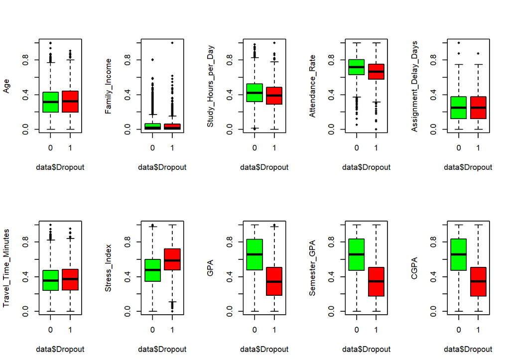

### Analisi dei missing

L’analisi esplorativa dei valori mancanti ne ha evidenziato la presenza, valutato l’entità e individuato eventuali pattern sistematici e associazioni tra le variabili coinvolte.

Dai grafici emerge che solo lo 0.8% dei dati risulta essere mancante.

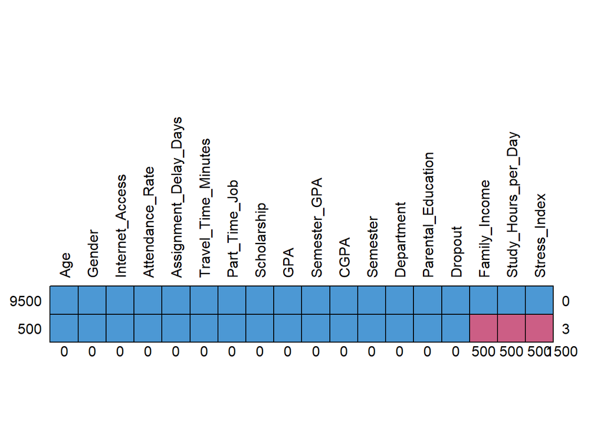

```
##      Age Gender Internet_Access Attendance_Rate Assignment_Delay_Days
## 9500   1      1               1               1                     1
## 500    1      1               1               1                     1
##        0      0               0               0                     0
##      Travel_Time_Minutes Part_Time_Job Scholarship GPA Semester_GPA CGPA
## 9500                   1             1           1   1            1    1
## 500                    1             1           1   1            1    1
##                        0             0           0   0            0    0
##      Semester Department Parental_Education Dropout Family_Income
## 9500        1          1                  1       1             1
## 500         1          1                  1       1             0
##             0          0                  0       0           500
##      Study_Hours_per_Day Stress_Index
## 9500                   1            1    0
## 500                    0            0    3
##                      500          500 1500
```

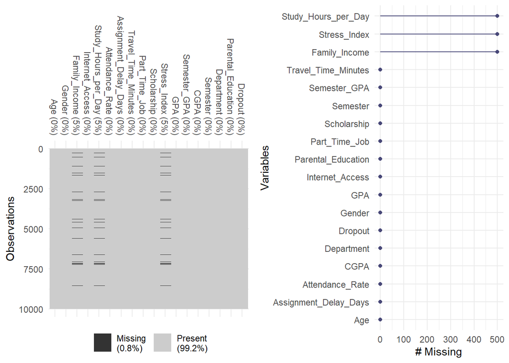

Si nota la presenza di valori mancanti nelle variabili Family_Income, Study_Hours_per_Day e Stress_index in 500 osservazioni. Queste variabili sono associate ad informazioni sensibili e personali, pertanto è possibile che alcuni studenti abbiano omesso volontariamente la risposta. Per questo motivo, risulta necessario un metodo opportuno di gestione dei missing.

### Selezione delle variabili

Infine, è stata analizzata la correlazione tra le variabili numeriche al fine di individuare eventuali relazioni lineari e possibili fenomeni di multicollinearità.

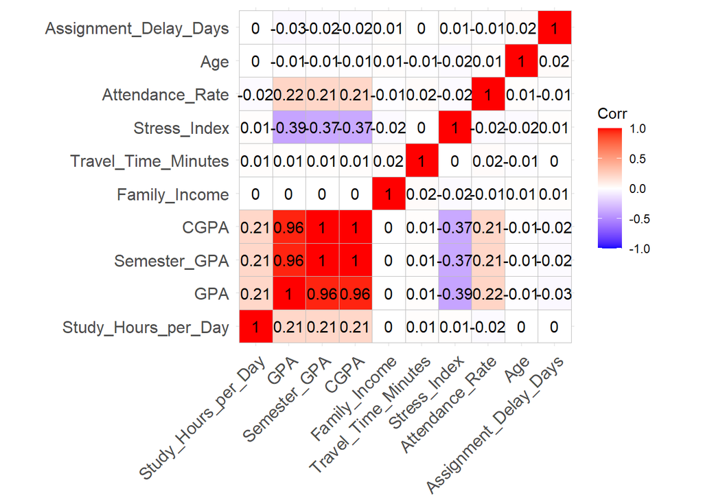

Notiamo che la correlazione tra le variabili GPA, Semester_GPA e CGPA è molto vicina ad 1. Considerando che esse descrivono in modo molto simile il rendimento accademico degli studenti, includerle tutte nelle analisi risulterebbe ridondante.

Abbiamo inoltre effettuato una selezione backward delle variabili al fine di mantenere nel modello le variabili più significative per prevedere la risposta. Il modello finale è composto da Family_Income, Internet_Access, Attendance_Rate, Assignment_Delay_Days, Travel_Time_Minutes, Part_Time_Job, Stress_Index e GPA.

Questa procedura ci ha permesso, oltre ad ottenere un modello parsimonioso, di escludere le variabili collineari, mantenendo GPA ed escludendo Semester GPA e CGPA.

## Data preparation

Per valutare il miglior metodo di imputazione e il modello ottimale per la classificazione, abbiamo diviso il nostro dataset in training (80%) e test set (20%). Abbiamo successivamente diviso ulteriormente il training set in train ridotto (80%) e validation (20%); su quest’ultimo abbiamo calcolato le metriche di valutazione accuracy e f1 score.

### Imputazione dei missing values

Al fine della gestione dei dati mancanti, si è ritenuto opportuno procedere con tecniche di imputazione, sia singola che multipla.

Sono stati considerati diversi metodi, in particolare:

- Mean: i missing vengono sostituiti con la media della variabile, riducendo la variabilità dei dati;
- PMM: modello semi-parametrico che imputa valori selezionandoli da osservazioni simili, preservando la distribuzione originale;
- Lasso norm: utilizza relazioni lineari tra le variabili per stimare i valori mancanti;
- Cart: metodo basato su alberi decisionali che imputano valori mancanti sfruttando relazioni non lineari tra le variabili.

I diversi metodi sono stati applicati al train ridotto e valutati, tramite opportuni modelli, sul validation set.

```r
f1_score <- function(cm) {
  TP <- cm[2,2]
  FP <- cm[1,2]
  FN <- cm[2,1]

  precision <- TP / (TP + FP)
  recall <- TP / (TP + FN)

  f1 <- 2 * precision * recall / (precision + recall)
  return(f1)
}
```

```
##                  pmm      mean lasso.norm      cart
## accuracies 0.8104705 0.8117959  0.8111332 0.8117959
## f1         0.5000000 0.5052265  0.5026178 0.5034965
```

Il metodo di imputazione migliore, sia secondo accuracy che F1 score, risulta essere quello tramite media, nonostante, rispetto agli altri metodi, tenda a ridurre la variabilità ed alterare le relazioni tra le variabili.

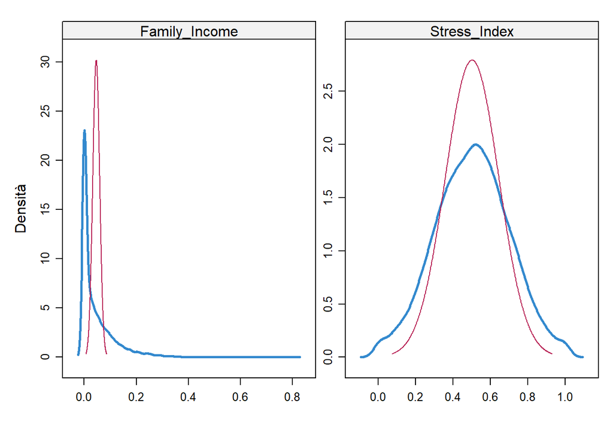

I missing values presenti nel validation e test set sono stati sostituiti con i valori imputati nel train ridotto, ovvero il valore atteso calcolato sui dati osservati.

Dall’analisi della variabile risposta, emerge uno sbilanciamento delle classi, con una prevalenza di studenti che completano gli studi.

```
##
##    0    1
## 4859 1541
```

Per affrontare questo problema sono state considerate tre strategie:

- dati originali;
- undersampling : riduzione delle osservazioni della classe maggioritaria;
- oversampling : duplicazione delle osservazioni della classe minoritaria.

Ci aspettiamo che i metodi di resampling aiutino il modello nella classificazione della classe minoritaria.

## Modelling

Sono stati considerati diversi modelli di classificazione su ogni strategia e sono state confrontate le performance:

- LDA : modello discriminante lineare che assume distribuzioni gaussiane per le variabili e uguale matrice di covarianza tra le classi;
- QDA: modello discriminante quadratico che assume distribuzioni gaussiane e matrici di covarianza diverse tra le classi, permettendo linee di confine non lineari;
- Regressione logistica: modello probabilistico utilizzato per la classificazione binaria;
- GLM con soglia ottimizzata: variante della regressione logistica in cui la soglia decisionale viene scelta in modo da ottimizzare l’F1-score sul validation set;
- Alberi decisionali: modelli non parametrici che suddividono lo spazio delle variabili tramite regole decisionali;
- Random Forest: metodo basato su più alberi decisionali che unisce le previsioni per ridurre l’overfitting, migliorando la stabilità e riducendo la varianza. Ogni albero viene istruito su un sottoinsieme casuale del training con reimmissione (campionamento bootstrap).

I diversi modelli sono stati valutati tramite le metriche qui riportate.

```r
calc_class_err = function(actual, predicted) {
  mean(actual != predicted)
}

metrics <- function(cm) {
  TP <- cm[2,2]
  FP <- cm[1,2]
  FN <- cm[2,1]
  TN <- cm[1,1]

  precision <- TP / (TP + FP)
  recall <- TP / (TP + FN)
  specificity <- TN / (TN + FP)
  accuracy <- (TP + TN) / sum(cm)
  f1 <- 2 * precision * recall / (precision + recall)

  return(list(
    Precision = precision,
    Recall = recall,
    Specificity = specificity,
    Accuracy = accuracy,
    F1_score = f1
  ))
}
```

## Evaluation

L’oversampling risulta la tecnica più efficace per la gestione dello sbilanciamento delle classi. Utilizzare i dati senza resampling, infatti, nonostante porti valori dell’accuracy molto elevati, presenta una scarsa capacità predittiva sulla classe minoritaria, in quanto il modello non apprende sufficientemente le informazioni necessarie per una classificazione adeguata. Le tecniche di under e over sampling, invece, migliorano le performance dei modelli. Si è scelto di adottare l’oversampling in quanto consente di bilanciare le classi senza perdita di informazioni (come si verifica nell’undersampling). La selezione finale del nostro modello è stata effettuata in base al punteggio F1-score, in quanto presenta il miglior equilibrio tra recall (tasso di veri positivi) e precision (capacità di prevedere in modo positivo un’istanza positiva). Il modello con F1-score maggiore è la regressione logistica con ottimizzazione della soglia decisionale, che garantisce un minor errore di classificazione della classe minoritaria.

```
## $`dati normali`
##                Error Precision    Recall Specificity Accuracy  F1_score
## LDA           0.1865 0.4476615 0.6165644   0.8518519   0.8135 0.5187097
## QDA           0.1860 0.4699332 0.6115942   0.8561934   0.8140 0.5314861
## GLM           0.1815 0.4387528 0.6396104   0.8510638   0.8185 0.5204756
## GLM_OPT       0.1995 0.5506073 0.6057906   0.8568665   0.8005 0.5768823
## TREE          0.1950 0.4253898 0.5913313   0.8461538   0.8050 0.4948187
## Random Forest 0.2005 0.4053452 0.5759494   0.8414489   0.7995 0.4758170
##
## $undersampling
##                Error Precision    Recall Specificity Accuracy  F1_score
## LDA           0.2710 0.7683742 0.4406130   0.9145440   0.7290 0.5600649
## QDA           0.2855 0.7728285 0.4252451   0.9138514   0.7145 0.5486166
## GLM           0.2665 0.7683742 0.4457364   0.9151713   0.7335 0.5641864
## GLM_OPT       0.1975 0.5560166 0.5968820   0.8620245   0.8025 0.5757250
## TREE          0.2970 0.7817372 0.4144038   0.9150043   0.7030 0.5416667
## Random Forest 0.2745 0.7639198 0.4363868   0.9126853   0.7255 0.5554656
##
## $oversampling
##                Error Precision    Recall Specificity Accuracy  F1_score
## LDA           0.2675 0.7728285 0.4448718   0.9163934   0.7325 0.5646867
## QDA           0.2775 0.7616927 0.4329114   0.9115702   0.7225 0.5520581
## GLM           0.2640 0.7683742 0.4486346   0.9155158   0.7360 0.5665025
## GLM_OPT       0.1895 0.5777778 0.5790646   0.8774984   0.8105 0.5784205
## TREE          0.2940 0.7750557 0.4167665   0.9133047   0.7060 0.5420561
## Random Forest 0.2060 0.5367483 0.5415730   0.8662379   0.7940 0.5391499
```

Per valutare ulteriormente le performance dei modelli, è stata analizzata la curva ROC e calcolata l’Area Under the Curve (AUC).

```r
roc = function(y, pred, soglia = seq(0,1,0.001)){
  y = as.numeric(y)-1
  TPR = numeric(length(soglia))
  FPR = numeric(length(soglia))
  for(i in 1:length(soglia)){
    y_pred = ifelse(pred>=soglia[i], 1,0)
    TP <- sum(y == 1 & y_pred == 1)
    FP <- sum(y == 0 & y_pred == 1)
    FN <- sum(y == 1 & y_pred == 0)
    TN <- sum(y == 0 & y_pred == 0)
    TPR[i] <- TP / (TP + FN)
    FPR[i] <- FP / (FP + TN)}
  data.frame(TPR,FPR)
}

auc = function(roc_res){
  a = 0
  for(i in 1:(nrow(roc_res)-1)){
    a = a - ((roc_res$FPR[i+1]-roc_res$FPR[i])*(roc_res$TPR[i+1]+roc_res$TPR[i])/2)}
  round(a,4)
}
```

I risultati evidenziano che:

- tutti i modelli hanno AUC > 0.5, indicando una capacità discriminante migliore del caso casuale
- le performance sono complessivamente simili
- nessun modello domina nettamente sugli altri

Tuttavia, il modello logistico risulta preferibile per la migliore gestione del trade-off tra falsi positivi e falsi negativi.

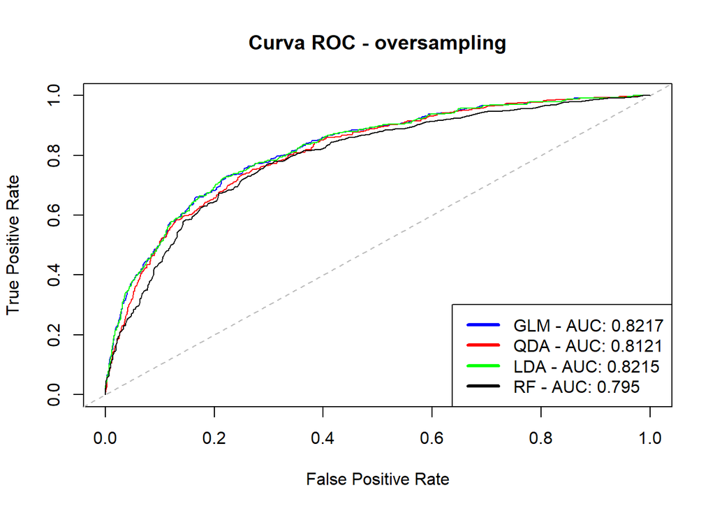

### Cross-validation

Abbiamo inoltre implementato una k-fold cross-validation per testare la robustezza dei risultati. Questa tecnica consiste nel dividere il dataset in k fold, che a turno fungono da test set. La performance viene valutata per ognuna delle partizioni e infine i risultati vengono aggregati tramite media.

```
##      Precision Recall Specificity Accuracy     F1
## LDA     0.6513 0.4393      0.9255   0.8084 0.5241
## QDA     0.6142 0.4517      0.9099   0.7995 0.5200
## GLM     0.6600 0.4231      0.9308   0.8086 0.5150
## TREE    0.6064 0.4483      0.9045   0.7947 0.5104
## RF      0.6208 0.4069      0.9208   0.7970 0.4904
```

```
##      Precision Recall Specificity Accuracy     F1
## LDA     0.4787 0.7619      0.7368   0.7428 0.5879
## QDA     0.4604 0.7469      0.7224   0.7283 0.5695
## GLM     0.4810 0.7541      0.7419   0.7448 0.5873
## TREE    0.4648 0.7288      0.7300   0.7297 0.5655
## RF      0.4688 0.7404      0.7337   0.7353 0.5740
```

```
##      Precision Recall Specificity Accuracy     F1
## LDA     0.4809 0.7619      0.7388   0.7444 0.5894
## QDA     0.4647 0.7534      0.7246   0.7316 0.5747
## GLM     0.4852 0.7625      0.7432   0.7478 0.5929
## TREE    0.4459 0.7586      0.6933   0.7091 0.5576
## RF      0.5715 0.5256      0.8747   0.7906 0.5468
```

Ne risulta che il modello GLM applicato ai dati sottoposti a oversampling risulta il migliore, anche con la tecnica CV.

## Deployment

La regressione logistica con soglia ottimizzata sui dati sottoposti a oversampling è il modello che viene proposto all’Università per prevedere l’abbandono degli studi, in quanto garantisce la miglior performance e classificazione della classe minoritaria. In seguito proponiamo un’analisi dettagliata del modello e delle variabili su cui porre una maggior attenzione per permettere a tutti gli studenti di completare i propri studi.

```r
summary(glm_fit)
```

```
##
## Call:
## glm(formula = Dropout ~ ., family = "binomial", data = dati_trn)
##
## Coefficients:
##                       Estimate Std. Error z value Pr(>|z|)
## (Intercept)            2.59699    0.18107  14.342  < 2e-16 ***
## Family_Income         -1.33636    0.35870  -3.726 0.000195 ***
## Internet_AccessYes    -0.45822    0.07279  -6.295 3.08e-10 ***
## Attendance_Rate       -1.83301    0.19056  -9.619  < 2e-16 ***
## Assignment_Delay_Days  1.31855    0.14266   9.243  < 2e-16 ***
## Travel_Time_Minutes    0.62861    0.14129   4.449 8.62e-06 ***
## Part_Time_JobYes       0.23853    0.04977   4.792 1.65e-06 ***
## Stress_Index           1.44631    0.13987  10.341  < 2e-16 ***
## GPA                   -4.53251    0.11498 -39.419  < 2e-16 ***
## ---
## Signif. codes:  0 '***' 0.001 '**' 0.01 '*' 0.05 '.' 0.1 ' ' 1
##
## (Dispersion parameter for binomial family taken to be 1)
##
##     Null deviance: 13472  on 9717  degrees of freedom
## Residual deviance: 10064  on 9709  degrees of freedom
## AIC: 10082
##
## Number of Fisher Scoring iterations: 4
```

Dall’analisi dei p-value tutti i coefficienti risultano statisticamente significativi: ciò significa che tutte le variabili incluse contribuiscono in modo rilevante alla previsione.

In termini probabilistici, i coefficienti del modello logistico possono essere interpretati come variazioni nei log-odds della probabilità di dropout, quindi evidenziano l’importanza relativa delle variabili nel determinare il rischio di abbandono.

In particolare:

- GPA, Family_Income, Internet_Access, Attendance_Rate hanno coefficiente negativo, indicando che un migliore rendimento accademico, una maggiore disponibilità economica , la possibilità di accesso alle piatteforme digitali e la partecipazione alle attività didattiche sono associati a una riduzione della probabilità di abbandono;
- i coefficienti positivi di Assignment_Delay_Days, Stress_Index, Travel_Time_Minutes e Part_Time_Job suggeriscono che maggiori difficoltà a rispettare le consegne, livelli elevati di stress, tempi di percorrenza più lunghi e la presenza di un impiego part-time sono fattori associati a un aumento del rischio di dropout.

Dal punto di vista operativo, il modello può essere utilizzato come strumento di supporto alle decisioni, permettendo all’università di identificare precocemente gli studenti a rischio e di attuare interventi mirati, quali attività di tutoraggio, supporto psicologico o sostegno economico. In particolare, risulta opportuno garantire l’accesso digitale agli studenti, potenziare il supporto economico per ridurre il ricorso al lavoro part-time, offrire servizi di supporto psicologico per la gestione dello stress e adottare un sistema di tassazione progressiva basato sul reddito familiare.